# 05. 데이터 전처리

## 1. 학습 안내

- 데이터 전처리를 **(1) 결측치 처리**와 **(2) 이상값 처리** 로 나누어 설명드리겠습니다.
- 이번 학습에는 R에 기본 내장되어 있는 **naniar 패키지의 riskfactors 데이터**를 활용하겠습니다.
- 먼저, 필요한 라이브러리를 호출합니다.

```r
#데이터 구조를 시각적으로 확인할 수 있는 visdat 패키지도 호출합니다.
pacman::p_load('tidyverse', 'naniar', 'visdat')
```

- 이제 오늘 활용할 riskfactors 데이터를 파악해 보겠습니다.
- str함수를 통해 riskfactors 데이터가 어떤 자료형과 어떤 구조로 되어 있는지 확인하실 수 있습니다.

```r
str(riskfactors)
```

```
## tibble [245 x 34] (S3: tbl_df/tbl/data.frame)
##  $ state           : Factor w/ 52 levels "1","2","5","6",..: 22 36 52 38 28 15 40 50 14 5 ...
##  $ sex             : Factor w/ 2 levels "Male","Female": 2 2 2 1 2 1 1 2 1 2 ...
##  $ age             : int [1:245] 49 48 55 42 66 66 37 62 38 42 ...
##  $ weight_lbs      : int [1:245] 190 170 163 230 135 165 150 170 146 260 ...
##  $ height_inch     : int [1:245] 64 68 64 74 62 70 68 70 70 73 ...
##  $ bmi             : num [1:245] 32.7 25.9 28 29.6 24.7 ...
##  $ marital         : Factor w/ 6 levels "Married","Divorced",..: 1 2 1 1 3 1 1 5 1 4 ...
##  $ pregnant        : Factor w/ 2 levels "Yes","No": NA NA NA NA NA NA NA NA NA 2 ...
##  $ children        : int [1:245] 0 0 0 1 0 0 3 0 2 3 ...
##  $ education       : Factor w/ 6 levels "1","2","3","4",..: 6 5 4 6 5 5 6 6 4 5 ...
##  $ employment      : Factor w/ 7 levels "1","2","3","4",..: 2 1 5 1 1 6 2 6 1 3 ...
##  $ income          : Factor w/ 10 levels "<10k","10-15k",..: 6 6 1 8 7 6 8 1 7 3 ...
##  $ veteran         : Factor w/ 5 levels "1","2","3","4",..: 5 5 5 5 5 3 5 5 5 5 ...
##  $ hispanic        : Factor w/ 2 levels "Yes","No": 2 2 1 2 2 2 2 2 2 2 ...
```

[output cut: 20 more lines]

- riskfactors 데이터는 34개의 변수(열)와 245개의 관측치(행)로 구성되어 있으며,  
  tibble 데이터 구조를 갖고 있음을 알 수 있습니다.

## 결측치 처리하기

### 결측치 제거

> **na.omit(데이터) : 데이터의 결측치를 제거하라**
- 데이터에 값이 들어 있지 않은 경우, NA로 표시가 됩니다.
- 저는 처음 데이터 분석을 진행할 때는 NA를 처리하지 않고 진행하시는 것을 추천 드립니다.
- NA가 한 개만 들어있어도 해당 줄을 다 날리기 때문에  
  아까운 다른 데이터까지 다 날려버릴 수도 있습니다.
- 아래의 예제를 보시면, na.omit으로 결측치를 날렸을 때  
  riskfactors의 관측치가 0으로, 모든 값 (행)이 없어진 것을 확인하실 수 있습니다.

```r
glimpse(na.omit(riskfactors))
```

```
## Rows: 0
## Columns: 34
## $ state            <fct>
## $ sex              <fct>
## $ age              <int>
## $ weight_lbs       <int>
## $ height_inch      <int>
## $ bmi              <dbl>
## $ marital          <fct>
## $ pregnant         <fct>
## $ children         <int>
## $ education        <fct>
## $ employment       <fct>
## $ income           <fct>
## $ veteran          <fct>
```

[output cut: 21 more lines]

- na.omit 함수 안에 데이터를 넣으시면 해당 데이터의 NA값이 포함된 관측치(행)을 제거합니다.

### 각 함수의 결측치 제거 옵션 활용

- 저는 결측지는 우선 그대로 두고, 분석을 진행해 보시는 것을 추천드립니다.
- 회귀, 상관 등 대부분의 분석 함수들이 na값을 제외하고 분석을 진행하는 옵션을 갖추고 있습니다.
- NA를 처리 하지 않은 상태에서 함수의 NA처리 옵션을 활용하여 돌려 보시고, 이후 NA를 처리하시고 돌려보시는 것을 추천 드립니다.
- 대부분의 함수에 na값을 제외하고 돌릴 수 있는 인자가 있습니다.
- sum 함수의 경우, na.rm 옵션으로 na값을 제외하고 구할 수 있습니다.
- 아래의 예를 보시면, na.rm 옵션이 없을 때는 결과가 NA가 나오지만,
- na.rm 옵션이 있을 때는 NA 값을 제외한 값들의 sum 결과가 표시됨을 보실 수 있습니다.

```r
# NA값이 포함되어 있는 데이터의 sum을 구하면, 결과값이 NA로 나옵니다.
sum(riskfactors$diet_fruit)
```

```
## [1] NA
```

```r
# sum 함수에서 NA값을 제거하고 sum하는 옵션인 na.rm=T 를 넣으면 값이 나옵니다.
sum(riskfactors$diet_fruit,na.rm=T)
```

```
## [1] 76956
```

- 회귀분석의 경우에는 na.action 옵션이 있습니다.
- na.action 옵션에 따라 잔차에 차이가 발생합니다.

[output not shown]

## 결측치 요약 및 시각화(naniar 패키지)

* naniar 패키지를 활용하시면 결측치를 쉽고 빠르게 파악하실 수 있습니다. * 우선 **miss_case_summary** 함수를 활용하시면 행 기준으로 결측치가 몇 개 있는지 결측치가 그 행의 전체 데이터 중 몇 퍼센트를 차지하는지 알려줍니다.

* **miss_var_summary** 함수는 열 기준으로 알려줍니다.

* **vis_miss** 함수를 활용하여 간단하게 시각화하여 확인할 수도 있습니다.

`r vis_miss(riskfactors)`

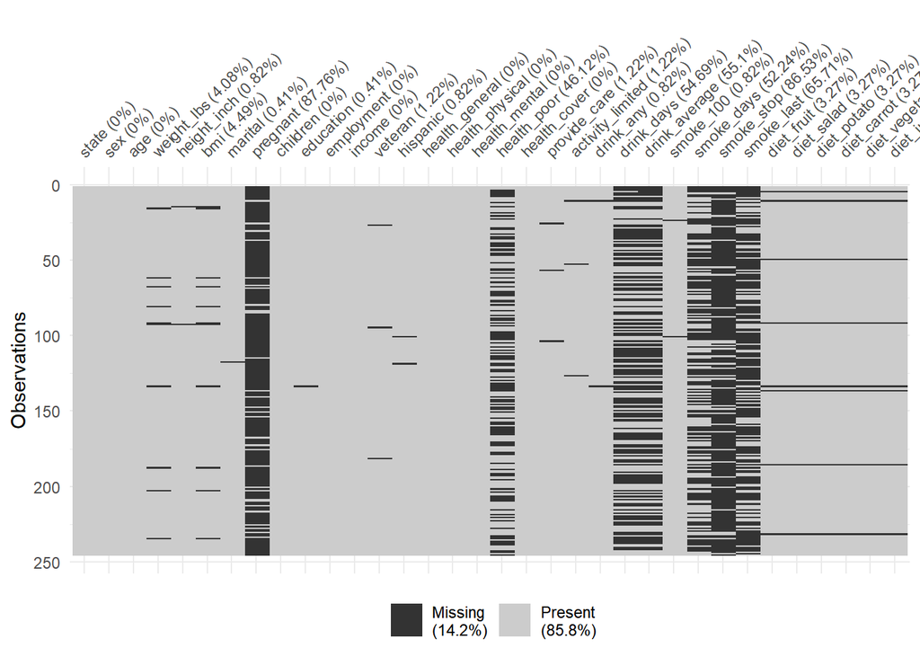

* **gg_miss_upset** 함수를 활용하시면, 어떤 패턴으로 결측치가 존재하는지 확인하실 수 있습니다.

* 아래의 예를 보시면, 5개 데이터가 모두 없는 경우가 72건으로 가장 많았고, 그 다음은 smoke_last, smoke_stop, pregnant 값이 없는 경우가 42건으로 많았습니다

`r gg_miss_upset(riskfactors)`

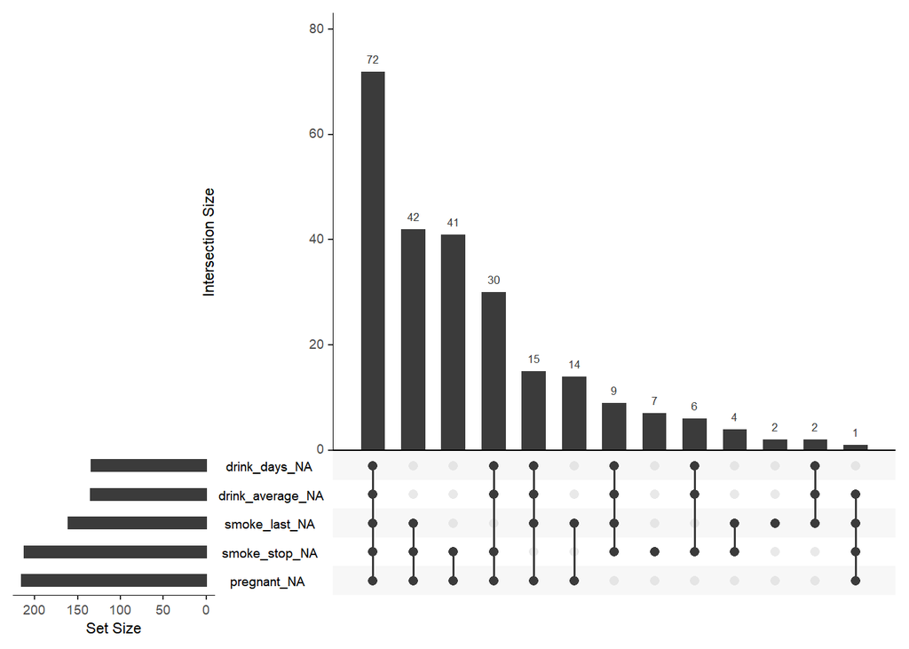

## 결측치 대체하기

- 저희가 보유하고 있는 데이터는 그 수가 많기에, 결측치를 대체하지 않고,  
  제거한 후 사용하여도 원하는 분석결과를 얻으실 수도 있습니다.
- 결측치를 대체하여 분석하기 원하신다면 아래의 포스팅 참고 부탁 드립니다.
- mice, rpart, DMwR 등의 패키지를 활용하여 결측치를 대체하실 수 있습니다.
- 자세한 내용은 아래 링크 참조 부탁 드립니다.

  [결측치 처리 기본개념](https://m.blog.naver.com/tjdudwo93/221142961499)  
  [결측치 처리(the book)](https://thebook.io/006723/ch09/02/02/)

# Data 전처리-이상치 처리

- 회귀, 상관 등 각종 분석을 진행 하다 보면, 이상치 유무에 따라 결과가 달라지는 것을 경험하게 됩니다.
- 제가 주로 분석하는 조직문화 데이터에는 불성실 응답 등 이상치가 꽤 포함되어 있습니다.
- 저는 문항 간 상관/회귀 등의 전반적인 트렌드를 볼 때 이상치를 제외하고 분석하고 있으며,  
  이러한 이상치들만 모아 놓고 이상치 탐색을 통해 이상치의 특성을 밝히는 작업도 하고 있습니다.
- 현업 데이터를 기준으로 분석을 진행하실 때는,  
  이상치 분석에는 크게 시간을 들이지 않으시는 것을 추천 드립니다.
- 분석을 진행하기 전에 간단하게 boxplot을 통해 이상치를 확인하시고,  
  이상치를 제거할지, 대체할지 판단하시어 제거/대체 하신 후 분석을 진행하시면 됩니다.
- 이번에는 R 내장 데이터인 mtcars 데이터를 활용하여 진행해보겠습니다.

## 이상치 확인

- 통계적으로 이상치를 판단하는 기준은 몇가지가 있지만,  
  저는 편하게, 상/하위 3 표준편차를 벗어나거나 1.5 IQR을 벗어나면  
  극단치(이상치)로 판단합니다.

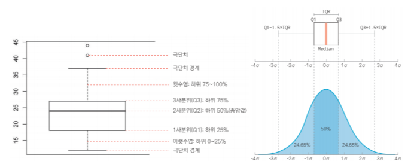

  이상치 한눈에 보기(출처: 실무에 써먹는 머신러닝(with R))

- 위 그림으로 보시면 더 명확하게 이해가 되실 것 같습니다.

$$하위\ 이상값은\\ 1분위수 - 1.5 \times (IQR:3분위수 - 1분위수) \ 보다\ 작은\ 값$$

$$상위\ 이상값은 \\ 3분위수 + 1.5 \times (IQR:3분위수 - 1분위수) \ 보다\ 큰\ 값$$

- R에서는 boxplot을 통해 간단하게 이상치가 있는지 확인하실 수 있습니다.  
  먼저, mtcars 데이터를 살펴볼까요?

```r
# tidyverse 라이브러리를 불러옵니다.
library(tidyverse)

# R 내장 데이터인 mtcars를 살펴봅니다.
glimpse(mtcars)
```

```
## Rows: 32
## Columns: 11
## $ mpg  <dbl> 21.0, 21.0, 22.8, 21.4, 18.7, 18.1, 14.3, 24.4, 22.8, 19.2, 17.8,~
## $ cyl  <dbl> 6, 6, 4, 6, 8, 6, 8, 4, 4, 6, 6, 8, 8, 8, 8, 8, 8, 4, 4, 4, 4, 8,~
## $ disp <dbl> 160.0, 160.0, 108.0, 258.0, 360.0, 225.0, 360.0, 146.7, 140.8, 16~
## $ hp   <dbl> 110, 110, 93, 110, 175, 105, 245, 62, 95, 123, 123, 180, 180, 180~
## $ drat <dbl> 3.90, 3.90, 3.85, 3.08, 3.15, 2.76, 3.21, 3.69, 3.92, 3.92, 3.92,~
## $ wt   <dbl> 2.620, 2.875, 2.320, 3.215, 3.440, 3.460, 3.570, 3.190, 3.150, 3.~
## $ qsec <dbl> 16.46, 17.02, 18.61, 19.44, 17.02, 20.22, 15.84, 20.00, 22.90, 18~
## $ vs   <dbl> 0, 0, 1, 1, 0, 1, 0, 1, 1, 1, 1, 0, 0, 0, 0, 0, 0, 1, 1, 1, 1, 0,~
## $ am   <dbl> 1, 1, 1, 0, 0, 0, 0, 0, 0, 0, 0, 0, 0, 0, 0, 0, 0, 1, 1, 1, 0, 0,~
## $ gear <dbl> 4, 4, 4, 3, 3, 3, 3, 4, 4, 4, 4, 3, 3, 3, 3, 3, 3, 4, 4, 4, 3, 3,~
## $ carb <dbl> 4, 4, 1, 1, 2, 1, 4, 2, 2, 4, 4, 3, 3, 3, 4, 4, 4, 1, 2, 1, 1, 2,~
```

- mtcars 데이터는 아래와 같은 변수로 구성되어 있습니다.

```
[, 1]   mpg Miles/(US) gallon
[, 2]   cyl Number of cylinders
[, 3]   disp    Displacement (cu.in.)
[, 4]   hp  Gross horsepower
[, 5]   drat    Rear axle ratio
[, 6]   wt  Weight (1000 lbs)
[, 7]   qsec    1/4 mile time
[, 8]   vs  Engine (0 = V-shaped, 1 = straight)
[, 9]   am  Transmission (0 = automatic, 1 = manual)
[,10]   gear    Number of forward gears
[,11]   carb    Number of carburetors
```

- mtcars 데이터의 wt 값의 이상치를 보기 위해 아래와 같이 박스플롯을 그려보았습니다.

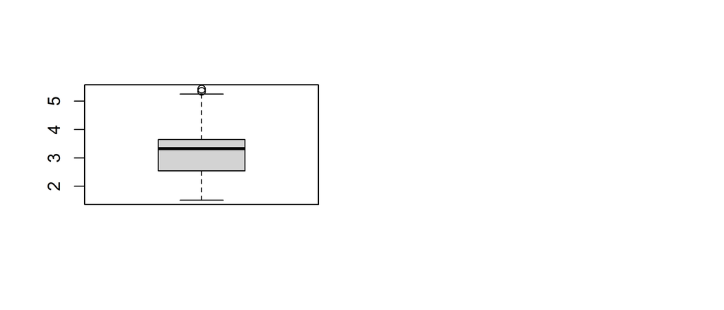

```r
# mtcars 데이터 중 wt데이터에 이상치가 있는지 살펴봅니다.
par(mfrow=c(1,2))
boxplot(mtcars$wt)
```

- 상위 극단치 경계값을 넘어가는 값이 보입니다.
- boxplot을 통해 위와 같이 극단치를 넘어가는 이상치가 있는 것으로 확인 된 경우,  
  아래와 같이 summary 함수, IQR 함수, which 함수를 통해 이상치가 포함되어 있는 행을 확인하실 수 있습니다.

```r
# summary 함수를 통해 분위수를 확인하고,
summary(mtcars$wt)
```

```
##    Min. 1st Qu.  Median    Mean 3rd Qu.    Max.
##   1.513   2.581   3.325   3.217   3.610   5.424
```

```r
# 3분위 값에 1.5IQR을 더한 상위 극단치보다 큰 값이 몇 행에 있는지 확인합니다.
which(mtcars$wt>summary(mtcars$wt)[5] + 1.5*IQR(mtcars$wt))
```

```
## [1] 15 16 17
```

```r
# 15, 16, 17번째 행의 wt 값이 이상치로 확인되었습니다.
# boxplot에서 확인했듯이 하위 극단치는 없는 것으로 나옵니다.
which(mtcars$wt<summary(mtcars$wt)[2] - 1.5*IQR(mtcars$wt))
```

```
## integer(0)
```

## 이상치 제거 및 대체

### 이상치 제거

- 앞서 상/하위 극단치를 확인 한 결과, 상위 극단치만 있는 것으로 확인 되었습니다.
- 이상치를 제거하기 위해서는 아래와 같이 이상치를 갖고 있는 행만 제거해주면 됩니다.

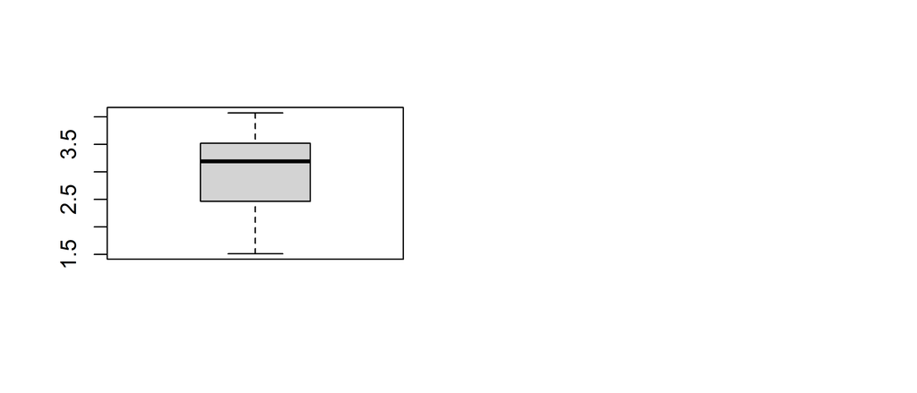

```r
mtcars_reshape <- mtcars[-which(mtcars$wt>summary(mtcars$wt)[5] + 1.5*IQR(mtcars$wt)),]
par(mfrow=c(1,2))
boxplot(mtcars_reshape$wt)
```

- mtcars[-which(mtcars$wt>summary(mtcars$wt)[5] + 1.5*IQR(mtcars$wt)),] 의 뜻은  
  mtcars 데이터 중, 극단치보다 높은 행만 - 제거 하겠다는 것입니다.
- 극단치보다 높은 값을 제거하고, 다시 박스플롯을 그려보니, 상위 극단치가 제거 되었음을 알 수 있습니다.

### 이상치 대체

- 이상치를 대체하고자 하시면, 아래와 같이 직접 값을 지정해주시면 됩니다.  
  저는 상위 극단치를 넘는 이상치를 NA 값으로 수정해보았습니다.

mtcars[which(mtcars$wt>summary(mtcars$wt)[5] + 1.5*IQR(mtcars$wt)),]$wt <- NA

- 위의 행을 실행하고 나면, 이상치가 있던 15,16,17행에 NA 값이 들어가 있는 것을 보실 수 있습니다.

```r
mtcars[which(mtcars$wt>summary(mtcars$wt)[5] + 1.5*IQR(mtcars$wt)),]$wt <- NA
mtcars$wt
```

```
##  [1] 2.620 2.875 2.320 3.215 3.440 3.460 3.570 3.190 3.150 3.440 3.440 4.070
## [13] 3.730 3.780    NA    NA    NA 2.200 1.615 1.835 2.465 3.520 3.435 3.840
## [25] 3.845 1.935 2.140 1.513 3.170 2.770 3.570 2.780
```

## 이상치 처리 패키지

- 이상치를 찾고 처리하기 위해  
  DMwR(카이제곱분포 활용), outlier(표준점수 활용), Grubb’s Test(편차 활용),  
  Robust Test(MAD(중간값과 Xi값 편차) 활용) 등 다양한 패키지와 함수들이 준비되어 있습니다.
- 더 자세한 내용에 대해서는 아래 URL 참고 부탁드립니다.

  [R 잡음 처리(MAF), 이상치 검출(카이제곱분포, LOF)](https://pubdata.tistory.com/53)

  [Missing Data, 이상치 처리 (DMwR)](https://analysis-flood.tistory.com/24)

  [Grubb’s Test, Robust Test](https://sosal.kr/945)